# Philippines Regressions

Tyler Clavelle

August 24, 2016

## Abstract

Traditionally, fishers and farmers have been treated as competitors (for space, within a market, for forage fish, for productivity), and fishers are often staunchly oppossed to aquaculture expansion. Aquaculture certainly interacts with wild fisheries in a number of ways, however the magnitude of these interactions is poorly known and quantified. This analysis uses provincial scale data on wild fisheries and aquaculture in the Philippines to examine if aquaculture activities impact wild fishery landings and value. Results show that, while aquaculture does indeed have a significant impact on wild fisheries, the impact is extremely small and varies by target fishery and aquaculture type (marine finfish, mussels, oysters, and seaweed).

## Introduction

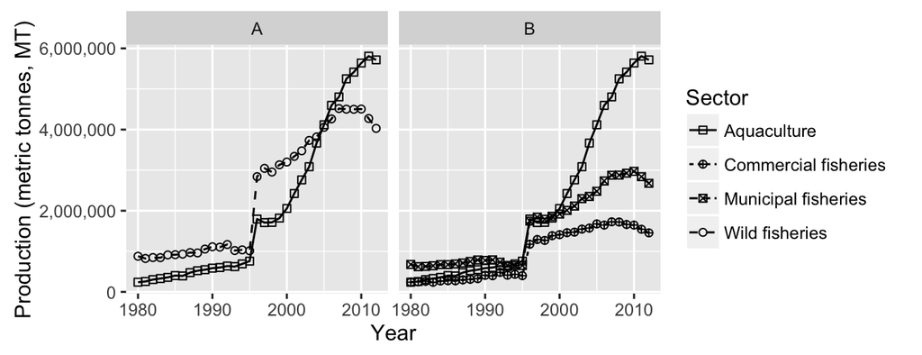

Annual production (MT) by marine sector in the Philippines from 1980 to 2012

Although these regulations ban fishing by the commercial fleet in municipal waters, illegal encroachment is believed to be rampant, with scaled-down commercial vessels, referred to as *‘baby trawlers’* operating extensively in municipal waters (Palomares, M. L. D., and D. Pauly, 2010).

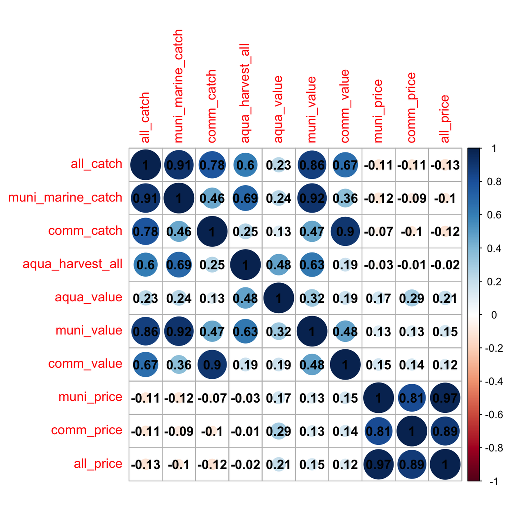

Correlation matrix of regression variables. Numbers represent correlation coefficients

## Materials and Methods

Data for this analysis comes from several sources. Fishery catch data for both the municipal and commercial sectors was obtained from the CountrySTAT Philippines data portal. These data include time series of catch (MT) and value for 31 species items organized by region and province.

### Results

|  | *Dependent variable:* |
| --- | --- |
|  | log(muni_marine_catch) |
| aqua_harvest | 0.00000*** |
|  | (0.00000) |
| culture_typeMussel | -0.024 |
|  | (0.030) |
| culture_typeOyster | -0.008 |
|  | (0.021) |
| culture_typeSeaweed | -0.028 |
|  | (0.020) |
| province_nameAKLAN | -0.253*** |
|  | (0.081) |
| province_nameANTIQUE | 0.672*** |
|  | (0.088) |
| province_nameAURORA | -0.638*** |
|  | (0.081) |
| province_nameBASILAN | 0.475*** |
|  | (0.081) |
| province_nameBATAAN | 0.121 |
|  | (0.089) |
| province_nameBATANGAS | 0.972*** |
|  | (0.093) |
| province_nameBILIRAN | -1.167*** |
|  | (0.088) |
| province_nameBOHOL | 0.826*** |
|  | (0.077) |
| province_nameBULACAN | -1.802*** |
|  | (0.095) |
| province_nameCAGAYAN | 0.876*** |
|  | (0.088) |
| province_nameCAMARINES NORTE | 1.032*** |

[output cut: 105 more lines]